# PEC 2 REGRESION

Sofía Zdral

17/6/2020

## PEC 2 Regresión, modelos y métodos

### *Ejercicio 1 (50 pt.)*

#### El archivo peru.txt contiene algunas variables posiblemente relacionadas con la presión sanguínea de n = 39 peruanos que se han trasladado de las zonas rurales de gran altitud a las zonas urbanas de menor altitud. Considerar un modelo de regresión múltiple para predecir la presión sistólica Y a partir de las variables:

- X1 = age
- X2 = years in urban area
- X3 = X2/X1 = fraction of life in urban area
- X4 = weight (kg)
- X5 = height (mm)
- X6 = chin skinfold
- X7 = forearm skinfold
- X8 = calf skinfold
- X9 = resting pulse rate

```r
#Lo primero que hacemos es cargar nuestros datos
data_peru<- read.delim("C:/Users/Sofia/Downloads/peru.txt")
summary(data_peru) #Y vemos que las variable son las que aparecían en el enunciado. Vemos que tenemos 2 columnas de datos, "Systol" y "Diastol", que aluden a la presión sistólica y diastólica respectivamente.
```

```
##       Age            Years           Weight          Height
##  Min.   :21.00   Min.   : 1.00   Min.   :53.00   Min.   :1473
##  1st Qu.:32.50   1st Qu.: 8.00   1st Qu.:57.00   1st Qu.:1537
##  Median :38.00   Median :13.00   Median :62.50   Median :1572
##  Mean   :36.54   Mean   :14.74   Mean   :63.16   Mean   :1579
##  3rd Qu.:41.50   3rd Qu.:19.00   3rd Qu.:68.00   3rd Qu.:1627
##  Max.   :54.00   Max.   :43.00   Max.   :87.00   Max.   :1653
##       Chin           Forearm            Calf            Pulse
##  Min.   : 3.000   Min.   : 1.300   Min.   : 0.000   Min.   :52.00
##  1st Qu.: 3.300   1st Qu.: 3.300   1st Qu.: 5.700   1st Qu.:64.00
##  Median : 5.300   Median : 5.000   Median : 7.700   Median :72.00
##  Mean   : 5.849   Mean   : 5.067   Mean   : 8.251   Mean   :70.31
##  3rd Qu.: 7.650   3rd Qu.: 5.850   3rd Qu.:11.300   3rd Qu.:76.00
##  Max.   :12.000   Max.   :12.700   Max.   :20.700   Max.   :92.00
##      Systol         Diastol
##  Min.   :106.0   Min.   : 54.00
##  1st Qu.:118.0   1st Qu.: 70.00
##  Median :126.0   Median : 76.00
##  Mean   :127.4   Mean   : 76.18
##  3rd Qu.:134.0   3rd Qu.: 81.00
##  Max.   :170.0   Max.   :120.00
```

```r
fraction_urban<-data_peru$Years/data_peru$Age #Creamos la variable que falta, "Fraction of life in urban area" (X3) y la llamaremos fraction_urban y a continuación la añadimos al dataset
data_peru<-as.data.frame(cbind(data_peru, fraction_urban))
head(data_peru) #Vemos que se ha añadido esta última variable
```

```
##   Age Years Weight Height Chin Forearm Calf Pulse Systol Diastol fraction_urban
## 1  21     1   71.0   1629  8.0     7.0 12.7    88    170      76     0.04761905
## 2  22     6   56.5   1569  3.3     5.0  8.0    64    120      60     0.27272727
## 3  24     5   56.0   1561  3.3     1.3  4.3    68    125      75     0.20833333
## 4  24     1   61.0   1619  3.7     3.0  4.3    52    148     120     0.04166667
## 5  25     1   65.0   1566  9.0    12.7 20.7    72    140      78     0.04000000
## 6  27    19   62.0   1639  3.0     3.3  5.7    72    106      72     0.70370370
```

#### (a) Estudiar la posible multicolinealidad de este modelo.

##### Empezamos creando el modelo de regresión y estudiando la correlación entre variables

```r
lm_systol<-lm(Systol~Age+Years+Weight+Height+Chin+Forearm+Calf+Pulse+fraction_urban, data=data_peru) #Creamos el modelo de regresión con la variable "Systol" como variable respuesta y el resto de variables del conjunto de datos como variables predictoras.
summary(lm_systol) #Aquellas variables predictoras que significativamente afectan a la variable respuesta a un nivel de confianza del 95% son: Age, Years, Weight y la derivada de las dos primeras, fraction_urban.
```

```
##
## Call:
## lm(formula = Systol ~ Age + Years + Weight + Height + Chin +
##     Forearm + Calf + Pulse + fraction_urban, data = data_peru)
##
## Residuals:
##      Min       1Q   Median       3Q      Max
## -12.3442  -6.3972   0.0507   5.7292  14.5257
##
## Coefficients:
##                  Estimate Std. Error t value Pr(>|t|)
## (Intercept)     146.81907   48.97096   2.998 0.005526 **
## Age              -1.12144    0.32741  -3.425 0.001855 **
## Years             2.45538    0.81458   3.014 0.005306 **
## Weight            1.41393    0.43097   3.281 0.002697 **
## Height           -0.03464    0.03686  -0.940 0.355194
## Chin             -0.94369    0.74097  -1.274 0.212923
## Forearm          -1.17085    1.19329  -0.981 0.334612
## Calf             -0.15867    0.53716  -0.295 0.769810
## Pulse             0.11455    0.17043   0.672 0.506818
## fraction_urban -115.29395   30.16900  -3.822 0.000648 ***
## ---
## Signif. codes:  0 '***' 0.001 '**' 0.01 '*' 0.05 '.' 0.1 ' ' 1
##
## Residual standard error: 8.655 on 29 degrees of freedom
## Multiple R-squared:  0.6674, Adjusted R-squared:  0.5641
## F-statistic: 6.465 on 9 and 29 DF,  p-value: 5.241e-05
```

```r
#Asimismo, el valor de R2 es de 0.67, moderado.

#El siguiente paso es ver las correlaciones entre las variables incluidas en el modelo
peru_df<-data.frame(data_peru)
cor(peru_df, method=c("pearson","kendall","spearman")) #Si nos fijamos en los valores de correlación entre las distintas variables, los más altos (vamos a considerar por encima de 0.6) se dan entre las variables fraction_urban y Years: 0.938, Calf y Forearm: 0.735, y entre Chin y Forearm: 0.637.
```

```
##                         Age        Years    Weight       Height         Chin
## Age             1.000000000  0.588212502 0.4316630  0.055777982  0.157908294
## Years           0.588212502  1.000000000 0.4811534  0.072594154  0.221697674
## Weight          0.431662982  0.481153366 1.0000000  0.450330307  0.561748764
## Height          0.055777982  0.072594154 0.4503303  1.000000000 -0.007898078
## Chin            0.157908294  0.221697674 0.5617488 -0.007898078  1.000000000
## Forearm         0.055202779  0.143024038 0.5437324 -0.068932124  0.637881501
## Calf           -0.005374411  0.001099438 0.3918655 -0.002845856  0.515999762
## Pulse           0.090654502  0.236904643 0.3117934  0.007829993  0.223100921
## Systol          0.005844807 -0.087480460 0.5213643  0.219114553  0.170192453
## Diastol         0.038725834  0.075792139 0.3944963  0.253040787  0.088787528
## fraction_urban  0.364523334  0.938145398 0.2930830  0.051187387  0.120091791
##                    Forearm         Calf       Pulse       Systol     Diastol
## Age             0.05520278 -0.005374411 0.090654502  0.005844807  0.03872583
## Years           0.14302404  0.001099438 0.236904643 -0.087480460  0.07579214
## Weight          0.54373244  0.391865474 0.311793359  0.521364290  0.39449626
## Height         -0.06893212 -0.002845856 0.007829993  0.219114553  0.25304079
## Chin            0.63788150  0.515999762 0.223100921  0.170192453  0.08878753
## Forearm         1.00000000  0.735525936 0.421907596  0.272280231  0.21237426
## Calf            0.73552594  1.000000000 0.208715412  0.250789289  0.30649050
## Pulse           0.42190760  0.208715412 1.000000000  0.135477107  0.05969512
## Systol          0.27228023  0.250789289 0.135477107  1.000000000  0.47519113
## Diastol         0.21237426  0.306490503 0.059695117  0.475191134  1.00000000
## fraction_urban  0.02801564 -0.113015720 0.214195184 -0.276145651 -0.05101308
##                fraction_urban
## Age                0.36452333
## Years              0.93814540
## Weight             0.29308303
## Height             0.05118739
## Chin               0.12009179
## Forearm            0.02801564
## Calf              -0.11301572
## Pulse              0.21419518
## Systol            -0.27614565
## Diastol           -0.05101308
## fraction_urban     1.00000000
```

```r
#Entre las dos primeras es normal que la correlación sea tan alta pues la primera es una variable derivada de la segunda.
```

##### Y después miramos los números de condición para ver si hay alguno mayor que 30 y por ende problemas de multicolinealidad.

```r
X<-model.matrix(lm_systol)
va<-eigen(t(X) %*% X)$values
sqrt(max(va)/va) #Vemos que sí hay varios números de condición > 30. Por tanto, vamos a ver los factores de inflación de la varianza a ver si el problema de multicolinealidad es grande.
```

```
##  [1]     1.0000   127.0065   173.0381   268.2391   292.7051   495.9436
##  [7]   832.5080  1413.8724 34177.3789 56120.3576
```

```r
library(vctrs)
library(carData)
library(car)

vif(lm_systol) #Vemos que hay factores de inflacción de la varianza que son bajos como el de Pulse o Heigth pero hay muy altos, el de Years y el de fraction_urban
```

```
##            Age          Years         Weight         Height           Chin
##       3.213372      34.289194       4.747711       1.913991       2.063866
##        Forearm           Calf          Pulse fraction_urban
##       3.802313       2.414602       1.329233      24.387468
```

##### Con todo esto podemos decir que sí existen problemas de multicolinealidad.

#### (b) Eliminar una única observación de la muestra de forma que el modelo mejore apreciablemente. Razonar la elección.

##### Para elegir la observación a eliminar primero vamos a representar nuestro modelo

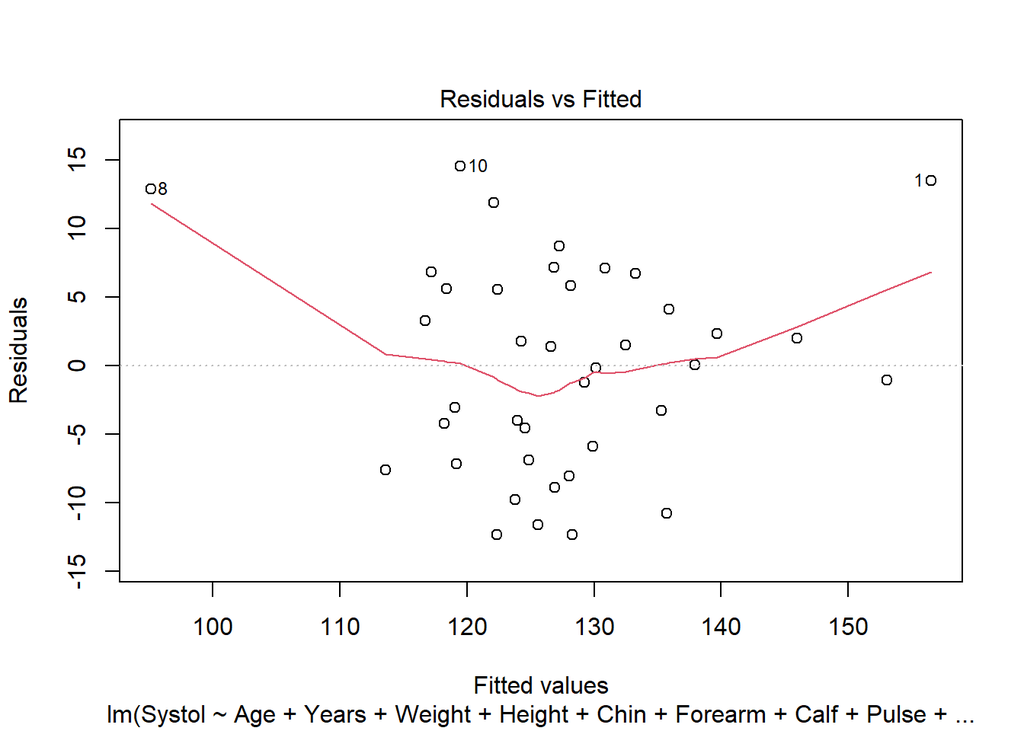

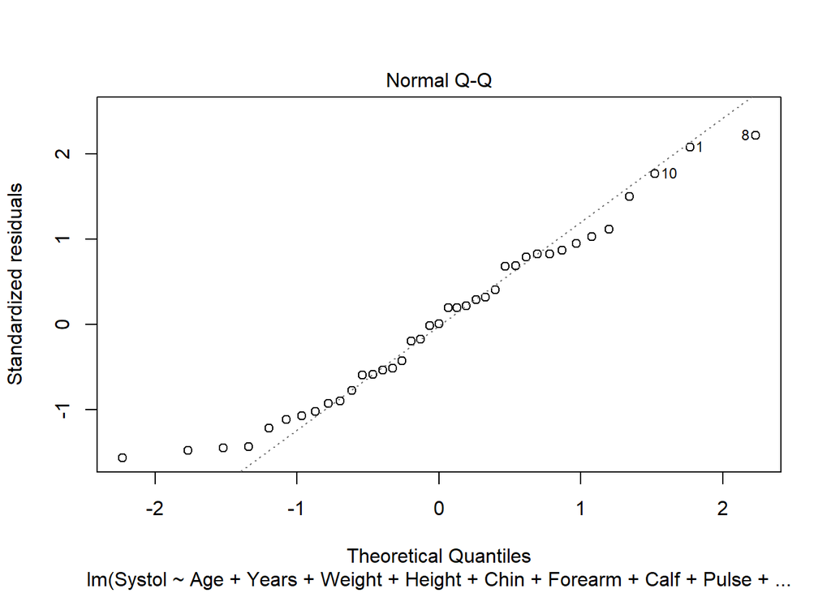

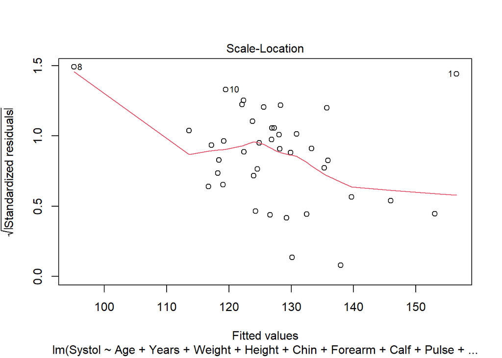

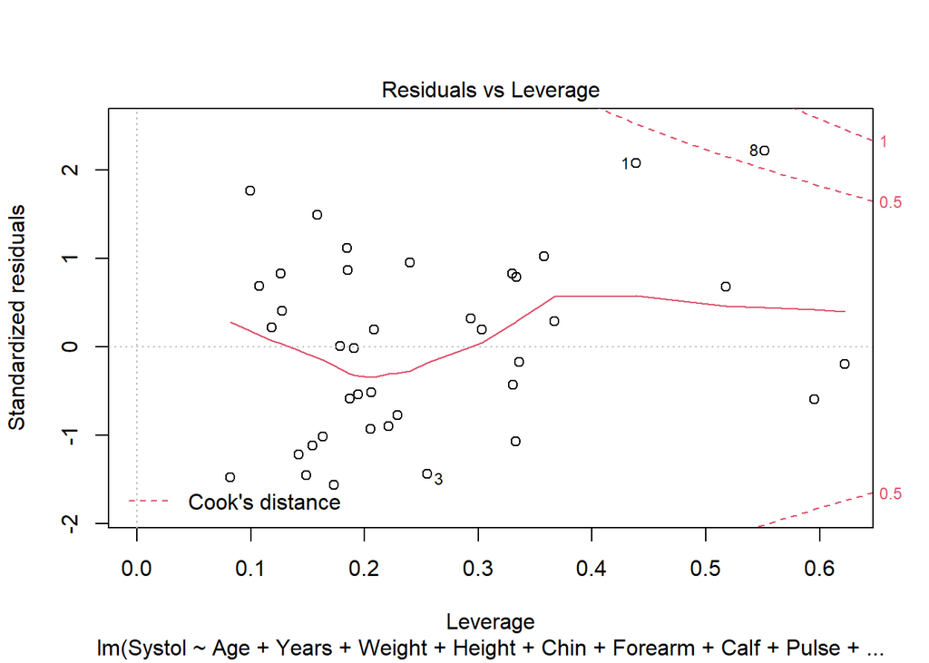

```r
plot(lm_systol) #Vemos en los cuatro gráficos que hay dos observaciones que se alejan mucho del resto de datos, el 1 y el 8. En concreto, la observación 8, en el gráfico 4 vemos que es el único con una distancia de Cook por encima de 0.5 de todo el conjunto de datos.
```

##### En base a lo observado, vamos a realizar algunos estudios adicionales para ver cuál eliminamos finalmente. Así, vamos a estudiar si existen observaciones con un alto Leverage

```r
#Lo primero que hacemos es guardar los leverages
hatv.systol <- hatvalues(lm_systol)
head(sort(hatv.systol,decreasing=T))  #Y mostramos las observaciones con mayores leverages
```

```
##        39        38         8         5         1         4
## 0.6220632 0.5951000 0.5517533 0.5178689 0.4388073 0.3671580
```

```r
sum(hatv.systol) #Miramos el sum(leverages), vemos que es 10
```

```
## [1] 10
```

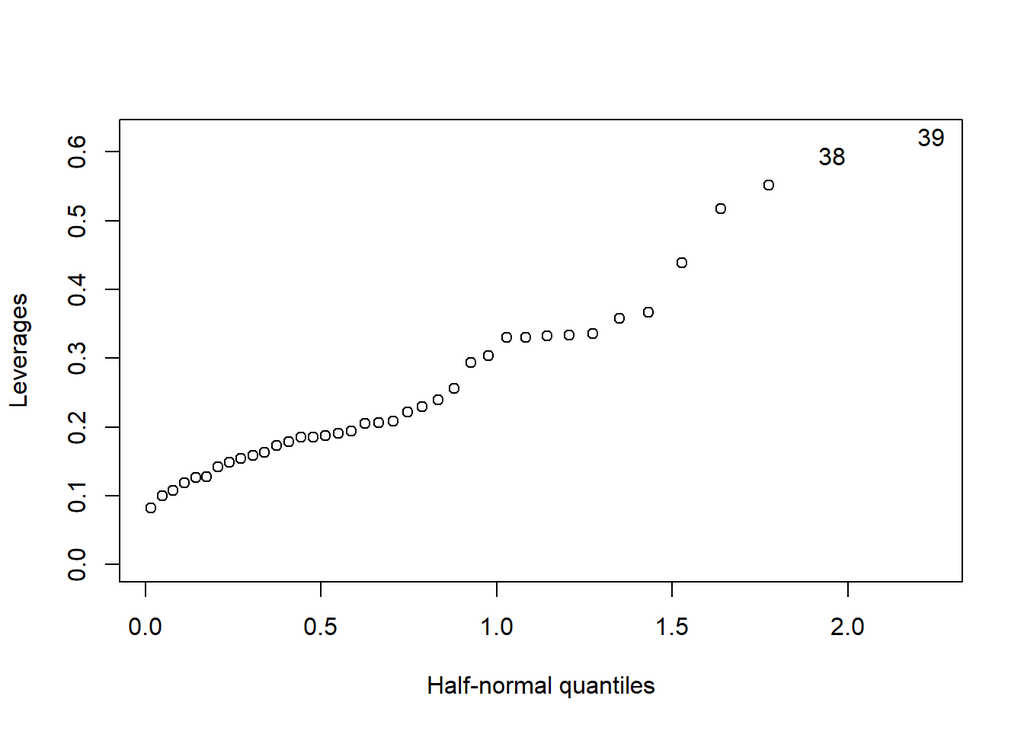

```r
#A continuación, realizamos el gráfico "half normal" y pediremos al programa que nos etiquete aquellos valores con leverage más alto.
library(faraway)
peru_leve <- row.names(data_peru)
halfnorm(hatv.systol, labs=peru_leve, ylab="Leverages") #Vemos que hay dos puntos, el 39 y el 38, que se alejan notablemente del resto de los datos.
```

```r
n<-39 #nº observaciones
p<-9 #nº variables predictoras

#Vamos a ver qué observaciones son las que están por encima de la media leverage:
leverage.mean<-p/n
which(hatv.systol > 2*leverage.mean) #Serían la 5,8,38 y 39
```

```
##  5  8 38 39
##  5  8 38 39
```

##### Vamos a retomar la distancia de Cook

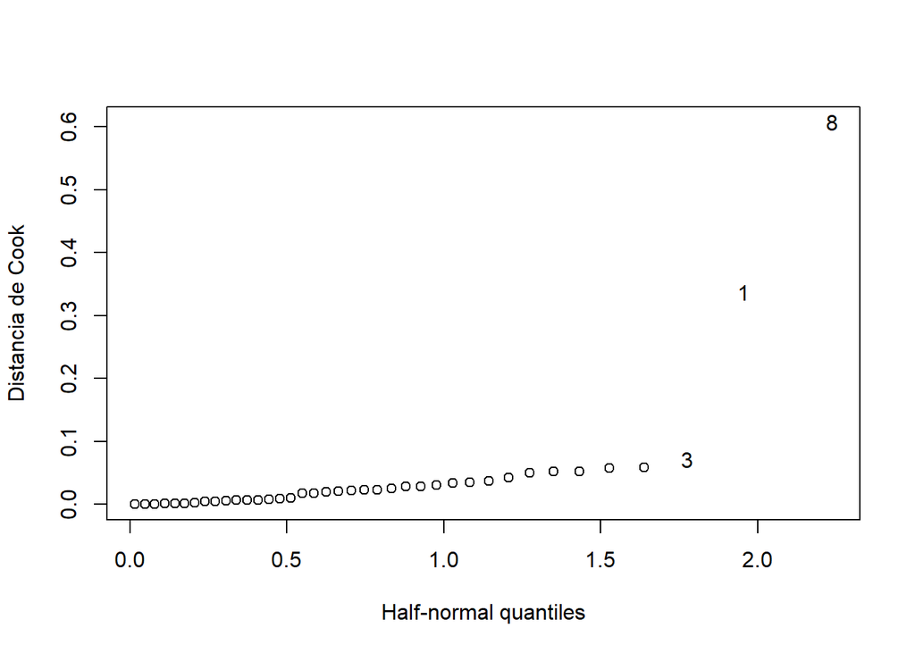

```r
#Como vimos en la representación gráfica al inicio del apartado, hay observaciones con distancias de Cook más altas.
cook<-cooks.distance(lm_systol)
halfnorm(cook,nlab=3,ylab="Distancia de Cook")
```

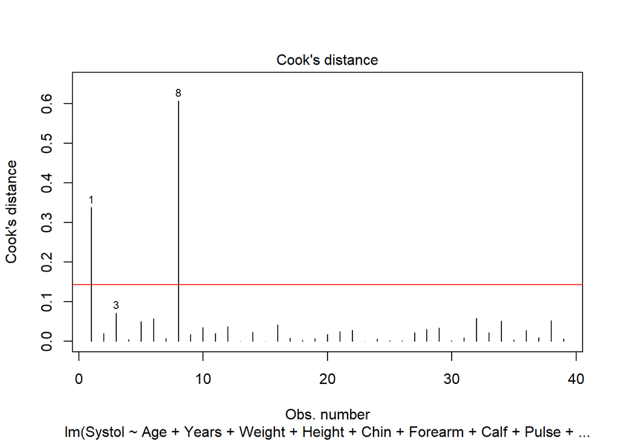

```r
plot(lm_systol, which=4)
abline(h=4/((n-p-2)), col="red") #Destacan la 1 y sobre todo la 8
```